# relation_of_size_and_ME

## Size dependance on overall ME

This demo shows the correlation of the size of the tree (or else, the number of the discrete points) with the decrease of Mean Error **for a given simple PDF**.

We expect for the ME decrease to depend directly to the shape of the tree and not the size. But because of the way that the adaption happens, there shape depends on the size **for small sizes**. A very small tree cannot take any shape, not only because of the lack of points but also because the possible positions of those points are all fixed. That means that the adaption is not and adaption of the points, but the selection of the right combination of points that create the shape we want.

In the following notebook, i present some different sizes (3, 15, 63, 127, 511, 1023, 4095) adapting on the same PDF.

```python
#!/usr/bin/python3
import sys
sys.path.insert(0, '../src/')

from ntree import *
from tree_vis import *

import numpy as np
import matplotlib.pyplot as plt
```

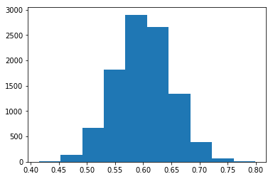

```python
space_dimensions = 1
sample_size = 10000
offsets = [0.1]
samples = np.random.normal(0.5, 0.05, size=sample_size*space_dimensions).reshape((sample_size, space_dimensions))
#move to the right offsets
samples = samples + np.array(list(offsets for i in range(sample_size)))

plt.hist(list(item[0] for item in samples))
plt.show()
```

```
Initial tree shape
```

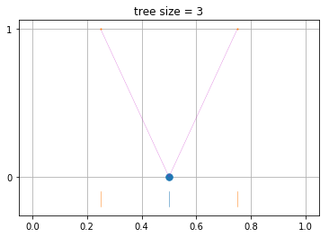

```
Adapted tree shape
```

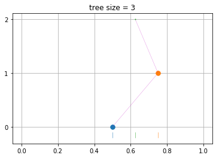

```
adapted after 2 steps
ME dropped to 38.0000861536869%
```

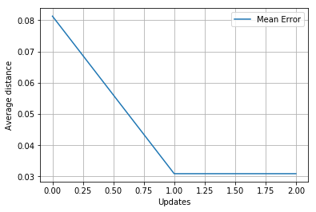

```
[0.08129664300993646, 0.030892794383831135, 0.030892794383831135]
```

```python
tree_size = 3

tree = Tree(space_dimensions, tree_size)
print('Initial tree shape')
tree.plot()

count = 0

tree.feed(samples)
ME = [tree.get_mean_error()]

while tree.update():
    tree.feed(samples)
    ME.append(tree.get_mean_error())
    count += 1
print('Adapted tree shape')
tree.plot()
print('adapted after {} steps'.format(count))
print('ME dropped to {}%'.format(100*np.min(ME)/np.max(ME)))
plt.plot(ME, label='Mean Error')
plt.xlabel('Updates')
plt.ylabel('Average distance')
plt.legend()
plt.grid(True)
plt.show()
print(ME)
```

```
Initial tree shape
```

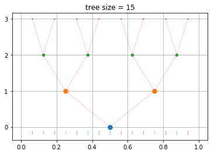

```
Adapted tree shape
```

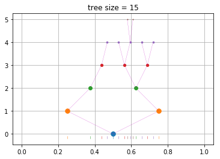

```
adapted after 2 steps
ME dropped to 38.493960418739285%
```

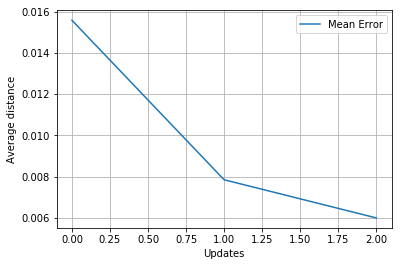

```
[0.015576998022984881, 0.007846075136579474, 0.005996203453395601]
```

```python
tree_size = 15

tree = Tree(space_dimensions, tree_size)
print('Initial tree shape')
tree.plot()

count = 0

tree.feed(samples)
ME = [tree.get_mean_error()]

while tree.update():
    tree.feed(samples)
    ME.append(tree.get_mean_error())
    count += 1
print('Adapted tree shape')
tree.plot()
print('adapted after {} steps'.format(count))
print('ME dropped to {}%'.format(100*np.min(ME)/np.max(ME)))
plt.plot(ME, label='Mean Error')
plt.xlabel('Updates')
plt.ylabel('Average distance')
plt.legend()
plt.grid(True)
plt.show()
print(ME)
```

```
Initial tree shape
```

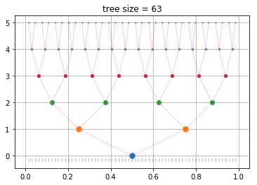

```
Adapted tree shape
```

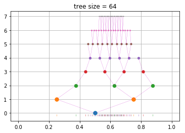

```
adapted after 4 steps
ME dropped to 28.421643405137235%
```

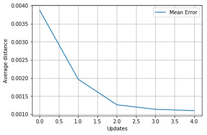

```
[0.0038705994395959293, 0.001964342527454845, 0.001260376062387463, 0.0011362848243286244, 0.0011000879703631952]
```

```python
tree_size = 63

tree = Tree(space_dimensions, tree_size)
print('Initial tree shape')
tree.plot()

count = 0

tree.feed(samples)
ME = [tree.get_mean_error()]

while tree.update():
    tree.feed(samples)
    ME.append(tree.get_mean_error())
    count += 1
print('Adapted tree shape')
tree.plot()
print('adapted after {} steps'.format(count))
print('ME dropped to {}%'.format(100*np.min(ME)/np.max(ME)))
plt.plot(ME, label='Mean Error')
plt.xlabel('Updates')
plt.ylabel('Average distance')
plt.legend()
plt.grid(True)
plt.show()
print(ME)
```

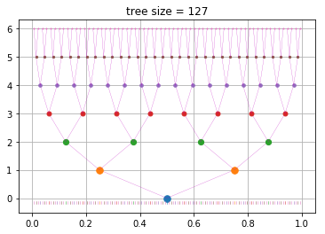

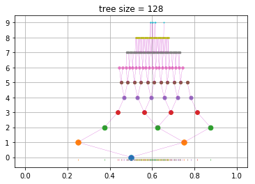

```
adapted after 5 steps
ME dropped to 26.99253803586118%
```

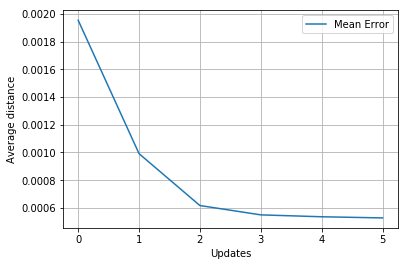

```
[0.0019546847300240485, 0.0009914935151231353, 0.0006169507571108615, 0.00054961471160146, 0.0005359231436137702, 0.0005276190192329117]
```

```python
tree_size = 127

tree = Tree(space_dimensions, tree_size)
print('Initial tree shape')
tree.plot()

count = 0

tree.feed(samples)
ME = [tree.get_mean_error()]

while tree.update():
    tree.feed(samples)
    ME.append(tree.get_mean_error())
    count += 1
print('Adapted tree shape')
tree.plot()
print('adapted after {} steps'.format(count))
print('ME dropped to {}%'.format(100*np.min(ME)/np.max(ME)))
plt.plot(ME, label='Mean Error')
plt.xlabel('Updates')
plt.ylabel('Average distance')
plt.legend()
plt.grid(True)
plt.show()
print(ME)
```

```
Initial tree shape
```

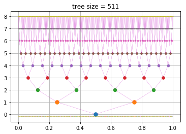

```
Adapted tree shape
```

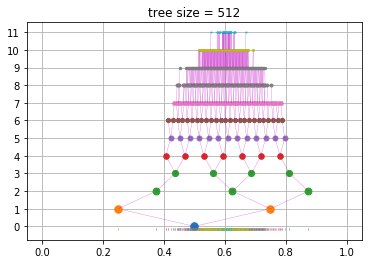

```
adapted after 7 steps
ME dropped to 26.27886008456868%
```

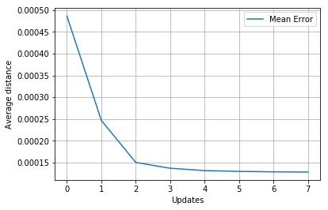

```
[0.00048668624386412167, 0.0002466009344293309, 0.00014995366766015972, 0.00013662438049648936, 0.00013123984612099112, 0.00012938945213526517, 0.00012836413144030447, 0.00012789559707589526]
```

```python
tree_size = 511

tree = Tree(space_dimensions, tree_size)
print('Initial tree shape')
tree.plot()

count = 0

tree.feed(samples)
ME = [tree.get_mean_error()]

while tree.update():
    tree.feed(samples)
    ME.append(tree.get_mean_error())
    count += 1
print('Adapted tree shape')
tree.plot()
print('adapted after {} steps'.format(count))
print('ME dropped to {}%'.format(100*np.min(ME)/np.max(ME)))
plt.plot(ME, label='Mean Error')
plt.xlabel('Updates')
plt.ylabel('Average distance')
plt.legend()
plt.grid(True)
plt.show()
print(ME)
```

```
Initial tree shape
```

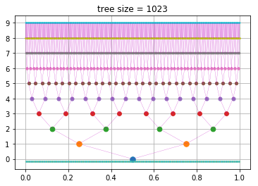

```
Adapted tree shape
```

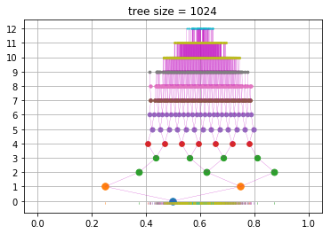

```
adapted after 8 steps
ME dropped to 25.386072970114537%
```

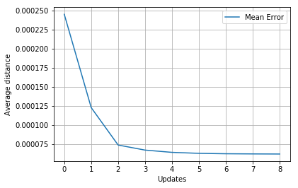

```
[0.0002452144728547518, 0.0001230278995599928, 7.402534501194266e-05, 6.738662545853351e-05, 6.443124134475673e-05, 6.31378888120898e-05, 6.259490007666656e-05, 6.23810607422002e-05, 6.225032501218899e-05]
```

```python
tree_size = 1023

tree = Tree(space_dimensions, tree_size)
print('Initial tree shape')
tree.plot()

count = 0

tree.feed(samples)
ME = [tree.get_mean_error()]

while tree.update():
    tree.feed(samples)
    ME.append(tree.get_mean_error())
    count += 1
print('Adapted tree shape')
tree.plot()
print('adapted after {} steps'.format(count))
print('ME dropped to {}%'.format(100*np.min(ME)/np.max(ME)))
plt.plot(ME, label='Mean Error')
plt.xlabel('Updates')
plt.ylabel('Average distance')
plt.legend()
plt.grid(True)
plt.show()
print(ME)
```

```
Initial tree shape
```

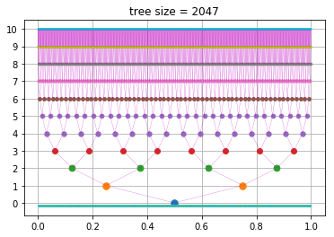

```
Adapted tree shape
```

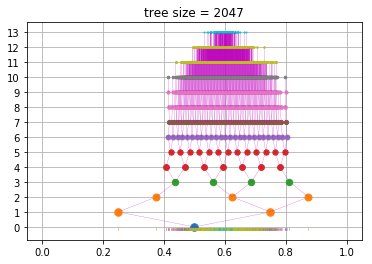

```
adapted after 9 steps
ME dropped to 25.276126624405595%
```

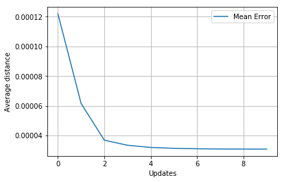

```
[0.00012195842897432802, 6.153911138373372e-05, 3.685133305527414e-05, 3.341880465180619e-05, 3.194117056199727e-05, 3.1365236687521255e-05, 3.104877932887514e-05, 3.0895330040873715e-05, 3.0838886273684506e-05, 3.082636693668691e-05]
```

```python
tree_size = 2047

tree = Tree(space_dimensions, tree_size)
print('Initial tree shape')
tree.plot()

count = 0

tree.feed(samples)
ME = [tree.get_mean_error()]

while tree.update():
    tree.feed(samples)
    ME.append(tree.get_mean_error())
    count += 1
print('Adapted tree shape')
tree.plot()
print('adapted after {} steps'.format(count))
print('ME dropped to {}%'.format(100*np.min(ME)/np.max(ME)))
plt.plot(ME, label='Mean Error')
plt.xlabel('Updates')
plt.ylabel('Average distance')
plt.legend()
plt.grid(True)
plt.show()
print(ME)
```

```
Initial tree shape
```

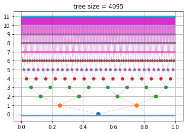

```
Adapted tree shape
```

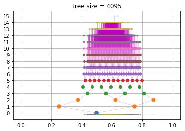

```
adapted after 10 steps
ME dropped to 22.835752228156807%
```

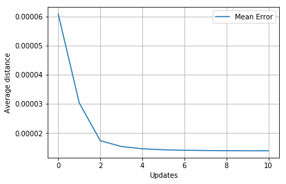

```
[6.082014886594969e-05, 3.02910137491337e-05, 1.733868689126561e-05, 1.5341367262674277e-05, 1.4574872272229356e-05, 1.4211262230795895e-05, 1.4052342196071277e-05, 1.3966741558174456e-05, 1.3916374769783046e-05, 1.3892719165179025e-05, 1.3888738499824393e-05]
```

```python
tree_size = 4095

tree = Tree(space_dimensions, tree_size)
print('Initial tree shape')
tree.plot()

count = 0

tree.feed(samples)
ME = [tree.get_mean_error()]

while tree.update():
    tree.feed(samples)
    ME.append(tree.get_mean_error())
    count += 1
print('Adapted tree shape')
tree.plot()
print('adapted after {} steps'.format(count))
print('ME dropped to {}%'.format(100*np.min(ME)/np.max(ME)))
plt.plot(ME, label='Mean Error')
plt.xlabel('Updates')
plt.ylabel('Average distance')
plt.legend()
plt.grid(True)
plt.show()
print(ME)
```

```
adapted after 30 steps
max level 18
ME dropped to 19.21411298515305%
```

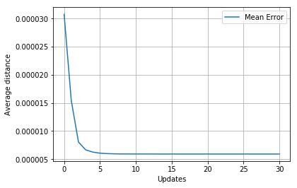

```
[3.0768919544345386e-05, 1.5406878402745494e-05, 8.047403678887998e-06, 6.652762062000794e-06, 6.254506800557913e-06, 6.066540162381562e-06, 5.9810772074924025e-06, 5.945226571205364e-06, 5.927490200410091e-06, 5.920249592389982e-06, 5.917271908347288e-06, 5.9147267693839045e-06, 5.914367119613384e-…
```

```python
tree_size = 8191

tree = Tree(space_dimensions, tree_size)
# print('Initial tree shape')
# tree.plot()

count = 0

tree.feed(samples)
ME = [tree.get_mean_error()]

while tree.update() and count<30:
    tree.feed(samples)
    ME.append(tree.get_mean_error())
    count += 1
print('adapted after {} steps'.format(count))
print('max level', np.max(list(node.get_level() for node in tree.get_nodes())))
print('ME dropped to {}%'.format(100*np.min(ME)/np.max(ME)))
plt.plot(ME, label='Mean Error')
plt.xlabel('Updates')
plt.ylabel('Average distance')
plt.legend()
plt.grid(True)
plt.show()
print(ME)
```

```
Adapted tree shape
```

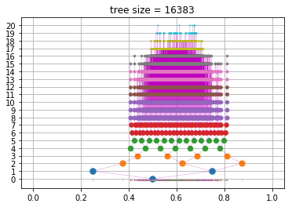

```
adapted after 15 steps
ME dropped to 14.789951142504929%
```

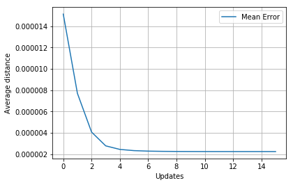

```
[1.5145621335160675e-05, 7.706297235276304e-06, 4.069137379345522e-06, 2.775347079683066e-06, 2.4415433420013397e-06, 2.3274219780206827e-06, 2.2812474702563866e-06, 2.2599947858532476e-06, 2.250234344981583e-06, 2.245417533603511e-06, 2.242085479178557e-06, 2.241391466709863e-06, 2.2404568324036477…
```

```python
tree_size = 16383

tree = Tree(space_dimensions, tree_size)
# print('Initial tree shape')
# tree.plot()

count = 0

tree.feed(samples)
ME = [tree.get_mean_error()]

while tree.update() and count<20:
    tree.feed(samples)
    ME.append(tree.get_mean_error())
    count += 1
print('Adapted tree shape')
tree.plot()
print('adapted after {} steps'.format(count))
print('ME dropped to {}%'.format(100*np.min(ME)/np.max(ME)))
plt.plot(ME, label='Mean Error')
plt.xlabel('Updates')
plt.ylabel('Average distance')
plt.legend()
plt.grid(True)
plt.show()
print(ME)
```

```
adapted after 30 steps
max level 22
ME dropped to 14.958260843464794%
```

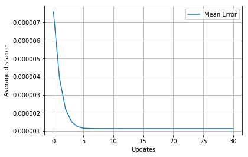

```
[7.577349727835203e-06, 3.927761878228508e-06, 2.2334754106344e-06, 1.5233416341272954e-06, 1.24099132503247e-06, 1.1553126879114362e-06, 1.141544132553418e-06, 1.136494244437325e-06, 1.1345962966313182e-06, 1.1339533187704753e-06, 1.1337332905521635e-06, 1.1335477303154539e-06, 1.1335609249751521e-…
```

```python
tree_size = 32767

tree = Tree(space_dimensions, tree_size)
# print('Initial tree shape')
# tree.plot()

count = 0

tree.feed(samples)
ME = [tree.get_mean_error()]

while tree.update() and count<30:
    tree.feed(samples)
    ME.append(tree.get_mean_error())
    count += 1
print('adapted after {} steps'.format(count))
print('max level', np.max(list(node.get_level() for node in tree.get_nodes())))
print('ME dropped to {}%'.format(100*np.min(ME)/np.max(ME)))
plt.plot(ME, label='Mean Error')
plt.xlabel('Updates')
plt.ylabel('Average distance')
plt.legend()
plt.grid(True)
plt.show()
print(ME)
```

```
adapted after 30 steps
max level 24
ME dropped to 22.404169109066377%
```

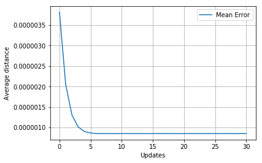

```
[3.8081758289587488e-06, 2.046572860642815e-06, 1.3077331431385564e-06, 1.014729147458049e-06, 9.039679270086088e-07, 8.660397951587461e-07, 8.53598230764352e-07, 8.539108932574702e-07, 8.531901526905084e-07, 8.538870538752241e-07, 8.532011482599189e-07, 8.539108957331342e-07, 8.532071087243964e-07,…
```

```python
tree_size = 65535

tree = Tree(space_dimensions, tree_size)
# print('Initial tree shape')
# tree.plot()

count = 0

tree.feed(samples)
ME = [tree.get_mean_error()]

while tree.update() and count<30:
    tree.feed(samples)
    ME.append(tree.get_mean_error())
    count += 1
print('adapted after {} steps'.format(count))
print('max level', np.max(list(node.get_level() for node in tree.get_nodes())))
print('ME dropped to {}%'.format(100*np.min(ME)/np.max(ME)))
plt.plot(ME, label='Mean Error')
plt.xlabel('Updates')
plt.ylabel('Average distance')
plt.legend()
plt.grid(True)
plt.show()
print(ME)
```

```
adapted after 30 steps
max level 24
ME dropped to 30.64229644348594%
```

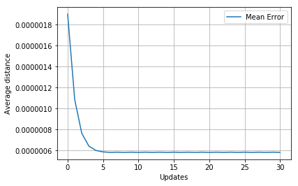

```
[1.900815833993652e-06, 1.085486219970211e-06, 7.630311237131537e-07, 6.422718598335764e-07, 6.005648910932027e-07, 5.869501482463791e-07, 5.824724059311115e-07, 5.84406009514582e-07, 5.824536226970545e-07, 5.844050841550374e-07, 5.824536226970545e-07, 5.844050841550374e-07, 5.824536226970545e-07, 5…
```

```python
tree_size = 131071

tree = Tree(space_dimensions, tree_size)
# print('Initial tree shape')
# tree.plot()

count = 0

tree.feed(samples)
ME = [tree.get_mean_error()]

while tree.update() and count<30:
    tree.feed(samples)
    ME.append(tree.get_mean_error())
    count += 1
print('adapted after {} steps'.format(count))
print('max level', np.max(list(node.get_level() for node in tree.get_nodes())))
print('ME dropped to {}%'.format(100*np.min(ME)/np.max(ME)))
plt.plot(ME, label='Mean Error')
plt.xlabel('Updates')
plt.ylabel('Average distance')
plt.legend()
plt.grid(True)
plt.show()
print(ME)
```

## Results

#### ME decrease

It is important to note that there is a great correlation in the PDF too. Some PDFs are easier to match while others may need a larger number of points to give the right fit to the tree. This has also to do with the base nodes. The more complex the PDF, the more nodes are needed for a base on which the tree will build the "shaping" nodes. Also the "width" of the PDF plays a big role. A PDF that is spread all over over the range can be optimized less that one that takes up a small portion. In the extreme case, if our PDF is a single point, then the tree will be a single line of nodes that reach this point (like a binary sarch), and the ME will approach to zero, depending on the closest float value on that point. The other extreme case is for the PDF to take up al the range in a way that the best adaption will be very close to a uniform tree. The mean error in this case will be the mean error of a uniform distribution, which mean that we have no decrease.

#### Adaption time

The number of the updates is needed for the tree to finally adapt, depends on the final shape and the changes that have to be made. On each update, the tree changes the outer nodes. This means that the regions changed can be one level taller or one level shorter. This constrain is set to make the progess more stable. There is ability to make further expansions and deeper cut at each update but this would lead to changes that has to be rolled back, while trying to adapt to the optimized form. And it is not going to save any decend time at all. The adaption time is already very fast due to the fact that the height of the trees is increasing with a logarithmicly related to the size. Also, because of the uniform initialization, the trees are already tall enough so the maximum level will be reached in a few updates. It takes more time to prune as deep as it needs, that to expand to the final height.